# R Notebook

```r
library(tidyverse)
library(janitor)
library(lubridate)
library(tsibbledata)
library(tsibble)
library(hms)
library(skimr)
library(slider)
library(infer)
library(leaflet)
library(fable)
```

| bike_id | start_time | stop_time | start_station | start_lat | start_long | end_station | end_lat | end_long | type | birth_year | gender |
| --- | --- | --- | --- | --- | --- | --- | --- | --- | --- | --- | --- |
| 26301 | 2018-02-26 19:11:03 | 2018-02-26 19:15:40 | 3186 | 40.71959 | -74.04312 | 3203 | 40.72760 | -74.04425 | Subscriber | 1986 | Male |
| 26301 | 2018-02-27 07:52:49 | 2018-02-27 07:58:13 | 3203 | 40.72760 | -74.04425 | 3202 | 40.72722 | -74.03376 | Subscriber | 1979 | Male |
| 26301 | 2018-02-27 12:03:27 | 2018-02-27 12:04:54 | 3202 | 40.72722 | -74.03376 | 3638 | 40.72429 | -74.03548 | Subscriber | 1963 | Male |
| 26301 | 2018-02-27 13:53:51 | 2018-02-27 14:21:04 | 3638 | 40.72429 | -74.03548 | 3638 | 40.72429 | -74.03548 | Subscriber | 1984 | Male |
| 26301 | 2018-02-27 14:30:42 | 2018-02-27 14:33:11 | 3638 | 40.72429 | -74.03548 | 3187 | 40.72112 | -74.03805 | Subscriber | 1980 | Male |
| 26301 | 2018-02-27 16:31:04 | 2018-02-27 16:33:27 | 3187 | 40.72112 | -74.03805 | 3638 | 40.72429 | -74.03548 | Subscriber | 1980 | Male |

Citi Bike is a privately owned public bicycle sharing system serving the New York City boroughs of the Bronx, Brooklyn, Manhattan, and Queens, as well as Jersey City, New Jersey, and Hoboken, New Jersey.

In October 2017 the system reached a total of 50 million rides and in July 2020 the system reached 100 million rides. As of July 2019, there are 169,000 annual subscribers. Monthly average ridership numbers increased above 100,000 for the first time in June 2021. The all-time record for single-day ridership occurred on September 9, 2022, when the system had 138,372 rides.

NYC’s Boris Bikes

Steps 1: Get an understaning of the dataset. Become familiar with columns names and data contained withing columns (data types).

Step 2: Understand the business questions.

Step 3: Investigations to work out the best analysis to do on the data set to answer the questions

Step 4: Perfom analyis and visulise the results

Step 5: Outline conclusions

| bike_id | start_time | stop_time | start_station | start_lat | start_long | end_station | end_lat | end_long | type | birth_year | gender | year | month | date | week | day | weekday | wday | time |
| --- | --- | --- | --- | --- | --- | --- | --- | --- | --- | --- | --- | --- | --- | --- | --- | --- | --- | --- | --- |
| 26301 | 2018-02-26 19:11:03 | 2018-02-26 19:15:40 | 3186 | 40.71959 | -74.04312 | 3203 | 40.72760 | -74.04425 | Subscriber | 1986 | Male | 2018 | February | 2018-02-26 | 9 | 26 | Monday | 2 | 19:00:00 |
| 26301 | 2018-02-27 07:52:49 | 2018-02-27 07:58:13 | 3203 | 40.72760 | -74.04425 | 3202 | 40.72722 | -74.03376 | Subscriber | 1979 | Male | 2018 | February | 2018-02-27 | 9 | 27 | Tuesday | 3 | 08:00:00 |
| 26301 | 2018-02-27 12:03:27 | 2018-02-27 12:04:54 | 3202 | 40.72722 | -74.03376 | 3638 | 40.72429 | -74.03548 | Subscriber | 1963 | Male | 2018 | February | 2018-02-27 | 9 | 27 | Tuesday | 3 | 12:00:00 |
| 26301 | 2018-02-27 13:53:51 | 2018-02-27 14:21:04 | 3638 | 40.72429 | -74.03548 | 3638 | 40.72429 | -74.03548 | Subscriber | 1984 | Male | 2018 | February | 2018-02-27 | 9 | 27 | Tuesday | 3 | 14:00:00 |
| 26301 | 2018-02-27 14:30:42 | 2018-02-27 14:33:11 | 3638 | 40.72429 | -74.03548 | 3187 | 40.72112 | -74.03805 | Subscriber | 1980 | Male | 2018 | February | 2018-02-27 | 9 | 27 | Tuesday | 3 | 15:00:00 |
| 26301 | 2018-02-27 16:31:04 | 2018-02-27 16:33:27 | 3187 | 40.72112 | -74.03805 | 3638 | 40.72429 | -74.03548 | Subscriber | 1980 | Male | 2018 | February | 2018-02-27 | 9 | 27 | Tuesday | 3 | 17:00:00 |
| 26301 | 2018-02-27 17:37:12 | 2018-02-27 17:40:49 | 3638 | 40.72429 | -74.03548 | 3639 | 40.71925 | -74.03423 | Subscriber | 1989 | Male | 2018 | February | 2018-02-27 | 9 | 27 | Tuesday | 3 | 18:00:00 |
| 26301 | 2018-02-27 17:49:10 | 2018-02-27 17:55:03 | 3639 | 40.71925 | -74.03423 | 3202 | 40.72722 | -74.03376 | Subscriber | 1962 | Male | 2018 | February | 2018-02-27 | 9 | 27 | Tuesday | 3 | 18:00:00 |
| 26301 | 2018-02-27 18:21:57 | 2018-02-27 18:25:18 | 3202 | 40.72722 | -74.03376 | 3638 | 40.72429 | -74.03548 | Subscriber | 1992 | Male | 2018 | February | 2018-02-27 | 9 | 27 | Tuesday | 3 | 18:00:00 |
| 26301 | 2018-02-27 22:08:55 | 2018-02-27 22:28:42 | 3638 | 40.72429 | -74.03548 | 3281 | 40.74591 | -74.05727 | Subscriber | 1981 | Male | 2018 | February | 2018-02-27 | 9 | 27 | Tuesday | 3 | 22:00:00 |

[output cut: 990 more lines]

Ethics: data could be used to track peoples movements

| age |
| --- |
| 19 |
| 20 |
| 21 |
| 22 |
| 23 |
| 24 |
| 25 |
| 26 |
| 27 |
| 28 |

[output cut: 44 more lines]

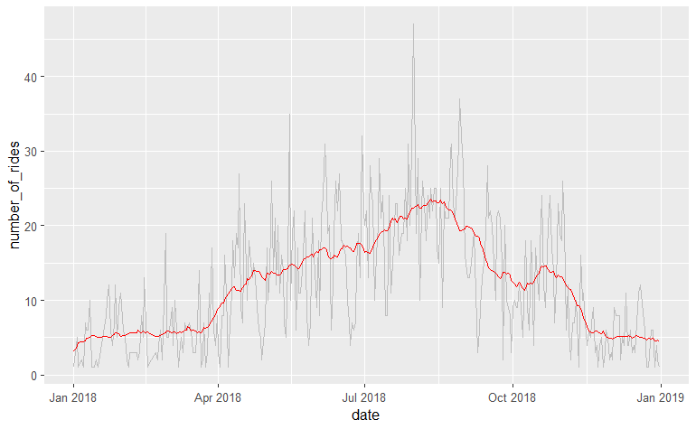

```r
bikes %>%
  index_by(date) %>%
  summarise(number_of_rides = n()) %>%
  mutate(n_rides_ma = slide_dbl(number_of_rides,
                             ~ mean(., na.rm = TRUE),
                             .before = 14,
                             .after = 14)) %>%
  ggplot(aes(x = date)) +
  geom_line(aes(y = number_of_rides), colour = "gray") +
  geom_line(aes(y = n_rides_ma), colour = "red")
```

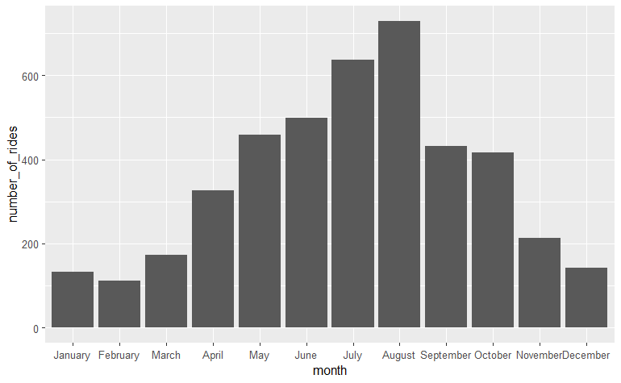

```r
bikes %>%
  index_by(month) %>%
  summarise(number_of_rides = n()) %>%
  ggplot() +
  geom_col(aes(x = month, y = number_of_rides, group = 1))
```

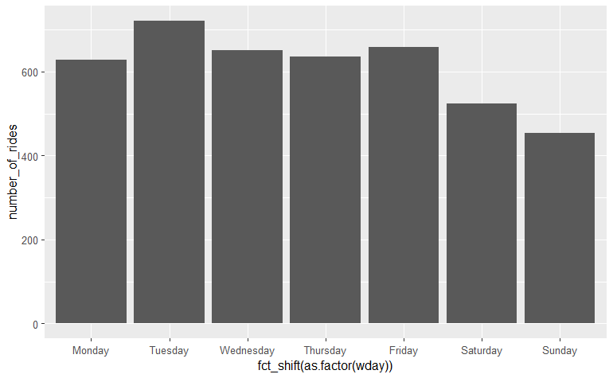

```r
bikes %>%
  index_by(wday) %>%
  summarise(number_of_rides = n()) %>%
  ggplot() +
  geom_col(aes(x = fct_shift(as.factor(wday)), y = number_of_rides)) +
  scale_x_discrete(labels = c("Monday","Tuesday", "Wednesday", "Thursday", "Friday", "Saturday", "Sunday"))
```

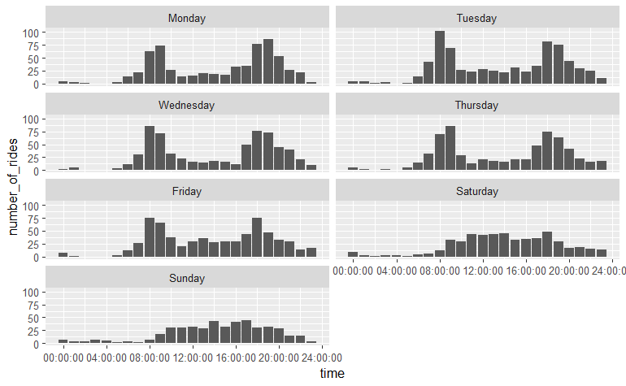

```r
bikes %>%
  index_by(time) %>%
  group_by(weekday) %>%
  summarise(number_of_rides = n()) %>%
  ggplot() +
  geom_col(aes(x = time, y = number_of_rides)) +
  facet_wrap(~weekday,ncol = 2)
```

```r
NA
```

gender bias

| prop_female |
| --- |
| 0.2325581 |

```r
bikes_m_f <- bikes %>%
  filter(gender != "Unknown")

null_distribution <- bikes_m_f %>%
  specify(response = gender, success = "Female") %>%
  hypothesise(null = "point", p = 0.5) %>%
  generate(reps = 1000, type = "draw") %>%
  calculate(stat = "prop")
```

[output not shown]

```r
age_brackets <- tibble(age_bracket = c("18 to 24 years", "25 to 34 years", "35 to 44 years", "45 to 54 years", "55 to 64 years", "over 64 years"), p = c(0.093, 0.145, 0.162, 0.135, 0.089, 0.128))

# change from prop of proportion to prop of eligible population

age_brackets_pop <- age_brackets %>%
  group_by(age_bracket) %>%
  summarise(prop = p / sum(age_brackets$p)) %>%
  ungroup() %>%
  mutate(pop_or_sample = "pop")



  ggplot() +
  geom_col(aes(x = age_bracket, y = prop))

age_brackets

?tibble
```

[figure not shown]

[interactive chart not shown]

```r
library(urca)
```

| bike_id | start_time | stop_time | start_station | start_lat | start_long | end_station | end_lat | end_long | type | birth_year | gender | year | month | date | week | day | weekday | wday | time | age | year_week |
| --- | --- | --- | --- | --- | --- | --- | --- | --- | --- | --- | --- | --- | --- | --- | --- | --- | --- | --- | --- | --- | --- |
| 26301 | 2018-02-26 19:11:03 | 2018-02-26 19:15:40 | 3186 | 40.71959 | -74.04312 | 3203 | 40.72760 | -74.04425 | Subscriber | 1986 | Male | 2018 | February | 2018-02-26 | 9 | 26 | Monday | 2 | 19:00:00 | 32 | 2018 W9 |
| 26301 | 2018-02-27 07:52:49 | 2018-02-27 07:58:13 | 3203 | 40.72760 | -74.04425 | 3202 | 40.72722 | -74.03376 | Subscriber | 1979 | Male | 2018 | February | 2018-02-27 | 9 | 27 | Tuesday | 3 | 08:00:00 | 39 | 2018 W9 |
| 26301 | 2018-02-27 12:03:27 | 2018-02-27 12:04:54 | 3202 | 40.72722 | -74.03376 | 3638 | 40.72429 | -74.03548 | Subscriber | 1963 | Male | 2018 | February | 2018-02-27 | 9 | 27 | Tuesday | 3 | 12:00:00 | 55 | 2018 W9 |
| 26301 | 2018-02-27 13:53:51 | 2018-02-27 14:21:04 | 3638 | 40.72429 | -74.03548 | 3638 | 40.72429 | -74.03548 | Subscriber | 1984 | Male | 2018 | February | 2018-02-27 | 9 | 27 | Tuesday | 3 | 14:00:00 | 34 | 2018 W9 |
| 26301 | 2018-02-27 14:30:42 | 2018-02-27 14:33:11 | 3638 | 40.72429 | -74.03548 | 3187 | 40.72112 | -74.03805 | Subscriber | 1980 | Male | 2018 | February | 2018-02-27 | 9 | 27 | Tuesday | 3 | 15:00:00 | 38 | 2018 W9 |
| 26301 | 2018-02-27 16:31:04 | 2018-02-27 16:33:27 | 3187 | 40.72112 | -74.03805 | 3638 | 40.72429 | -74.03548 | Subscriber | 1980 | Male | 2018 | February | 2018-02-27 | 9 | 27 | Tuesday | 3 | 17:00:00 | 38 | 2018 W9 |
| 26301 | 2018-02-27 17:37:12 | 2018-02-27 17:40:49 | 3638 | 40.72429 | -74.03548 | 3639 | 40.71925 | -74.03423 | Subscriber | 1989 | Male | 2018 | February | 2018-02-27 | 9 | 27 | Tuesday | 3 | 18:00:00 | 29 | 2018 W9 |
| 26301 | 2018-02-27 17:49:10 | 2018-02-27 17:55:03 | 3639 | 40.71925 | -74.03423 | 3202 | 40.72722 | -74.03376 | Subscriber | 1962 | Male | 2018 | February | 2018-02-27 | 9 | 27 | Tuesday | 3 | 18:00:00 | 56 | 2018 W9 |
| 26301 | 2018-02-27 18:21:57 | 2018-02-27 18:25:18 | 3202 | 40.72722 | -74.03376 | 3638 | 40.72429 | -74.03548 | Subscriber | 1992 | Male | 2018 | February | 2018-02-27 | 9 | 27 | Tuesday | 3 | 18:00:00 | 26 | 2018 W9 |
| 26301 | 2018-02-27 22:08:55 | 2018-02-27 22:28:42 | 3638 | 40.72429 | -74.03548 | 3281 | 40.74591 | -74.05727 | Subscriber | 1981 | Male | 2018 | February | 2018-02-27 | 9 | 27 | Tuesday | 3 | 22:00:00 | 37 | 2018 W9 |

[output cut: 990 more lines]

forecast

```r
bikes_forecast <- bikes_year_week %>%
  index_by((year_week)) %>%
  summarise(n = n())
```

[output not shown]

```r
bikes_forecast <- bikes %>%
  index_by((date)) %>%
  summarise(n = n()) %>%
  tsibble::fill_gaps(n = median(n))





fit <- bikes_forecast %>%
  model(
    snaive = SNAIVE(n),
    mean_model = MEAN(n),
    arima = ARIMA(log(n))
  )

forecast_1 <- fit %>%
  fabletools::forecast(h = "5 months")
forecast_1
```

| .model | (date) | n | .mean |
| --- | --- | --- | --- |
| snaive | 2019-01-01 |  | 10.000000 |
| snaive | 2019-01-02 |  | 6.000000 |
| snaive | 2019-01-03 |  | 6.000000 |
| snaive | 2019-01-04 |  | 1.000000 |
| snaive | 2019-01-05 |  | 4.000000 |
| snaive | 2019-01-06 |  | 2.000000 |
| snaive | 2019-01-07 |  | 1.000000 |
| snaive | 2019-01-08 |  | 10.000000 |
| snaive | 2019-01-09 |  | 6.000000 |
| snaive | 2019-01-10 |  | 6.000000 |

[output cut: 446 more lines]

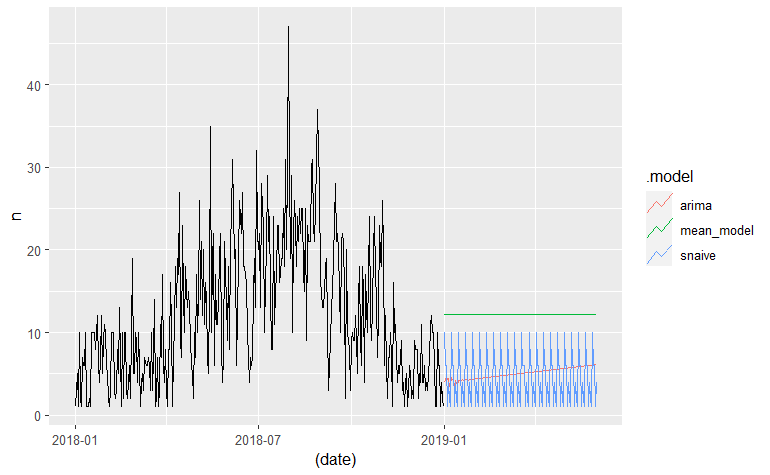

```r
forecast_1 %>%
  autoplot(bikes_forecast, level = NULL)
```

| month | n() |
| --- | --- |
| January | 2 |
| February | 3 |
| March | 4 |
| April | 7 |
| May | 7 |
| June | 7 |
| July | 7 |
| August | 8 |
| September | 8 |
| October | 6 |

[output cut: 2 more lines]

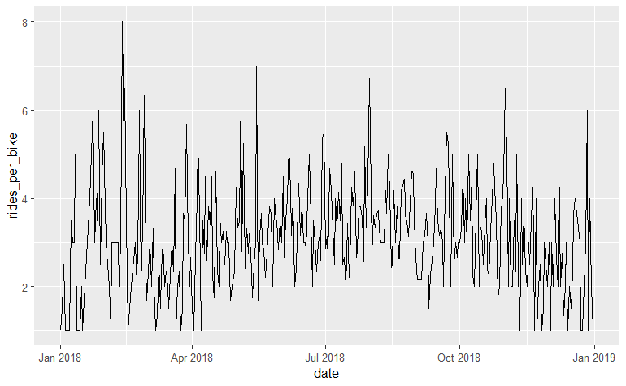

```r
bikes %>%
  index_by(date) %>%
  group_by(date, bike_id) %>%
  summarise(r = n()) %>%
  index_by(date) %>%
  summarise(n = n(),
            rides = sum(r),
            rides_per_bike = rides / n) %>%
  ggplot() +
  geom_line(aes(x = date, y = rides_per_bike, group = 1))
```

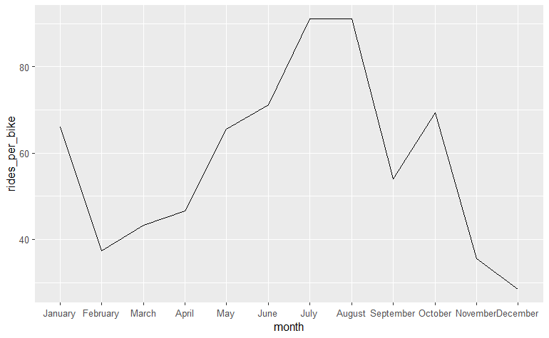

```r
bikes %>%
  index_by(month) %>%
  group_by(month, bike_id) %>%
  summarise(r = n()) %>%
  index_by(month) %>%
  summarise(n = n(),
            rides = sum(r),
            rides_per_bike = rides / n) %>%
  ggplot() +
  geom_line(aes(x = month, y = rides_per_bike, group = 1))
```

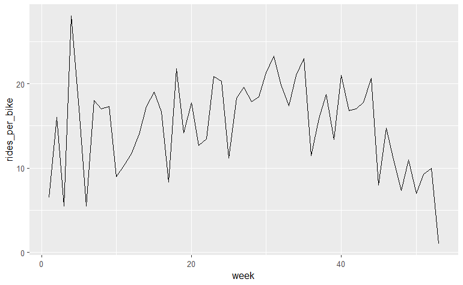

```r
bikes %>%
  index_by(week) %>%
  group_by(week, bike_id) %>%
  summarise(r = n()) %>%
  index_by(week) %>%
  summarise(n = n(),
            rides = sum(r),
            rides_per_bike = rides / n) %>%
  ggplot() +
  geom_line(aes(x = week, y = rides_per_bike))
```

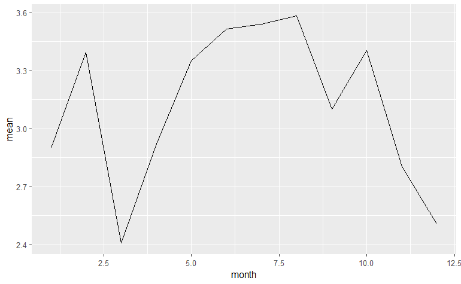

```r
bikes %>%
  index_by(date) %>%
  group_by(date, bike_id) %>%
  summarise(r = n()) %>%
  index_by(date) %>%
  summarise(n = n(),
            rides = sum(r),
            rides_per_bike = rides / n) %>%
  mutate(month = month(date)) %>%
  index_by(month) %>%
  summarise(mean = mean(rides_per_bike)) %>%
  ggplot() +
  geom_line(aes(x = month, y = mean))
```

```r
bikes %>%
  index_by(week) %>%
  group_by(week, bike_id) %>%
  summarise(n()) %>%
  summarise(n())
```

| week | n() |
| --- | --- |
| 1 | 2 |
| 2 | 2 |
| 3 | 2 |
| 4 | 2 |
| 5 | 2 |
| 6 | 2 |
| 7 | 2 |
| 8 | 1 |
| 9 | 3 |
| 10 | 4 |

[output cut: 43 more lines]

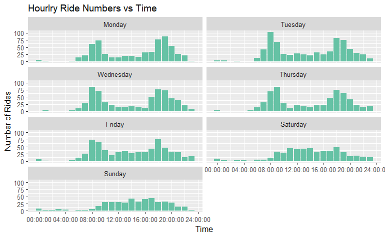

```r
bikes_time <- nyc_bikes %>%
  mutate(weekday = weekdays(start_time),
         time = as_hms(round_date(start_time, "hour"))) %>%
  mutate(across(weekday, factor, levels=c("Monday","Tuesday", "Wednesday", "Thursday", "Friday", "Saturday", "Sunday")))

bikes_time %>%
  index_by(time) %>%
  group_by(weekday) %>%
  summarise(number_of_rides = n()) %>%
  ggplot() +
  geom_col(aes(x = time, y = number_of_rides, fill = "blue")) +
  facet_wrap(~weekday,ncol = 2) +
  labs(title = "Hourlry Ride Numbers vs Time", y= "Number of Rides", x = "Time") +
  scale_fill_brewer(palette = "Set2") +
  guides(fill = "none")
```